# Статистика - 2 (набір 2026)

*Ваші відповіді ніде не зберігаються, нікуди не передаються. Цей опитувальник для само-контролю.*

#### Це блок питань по Заняттю 2, де показано, як дослідник оцінює явища, які спостерігає. Копіюйте та запускайте код в R.

## 1 Генеральна сукупність

У дослідженні маси дорослих кажанів усі особини певної популяції утворюють **генеральну сукупність**. Дослідник виміряв 12 випадково відібраних особин і отримав такі значення маси, г:

```r
mass <- c(18.2, 19.1, 17.8, 20.4, 18.9, 31.0,
          19.5, 18.7, 20.1, 17.9, 19.8, 18.9)
```

1. Поясніть різницю між параметром генеральної сукупності та статистикою (оцінкою параметра).
2. Обчисліть вибіркове середнє, медіану, дисперсію та стандартне відхилення.
- Середнє арифметичне значення > 19
- Медіана > 19
- Дисперсія = 12.62
3. Яка з мір центральної тенденції більш стійка до викидів?

   Медіана Середнє арифметичне значення

`mean(mass)`

Медіана - впорядкуйте числа, знайдіть центральні (6 і 7 елементи, це 18.9 і 19.1, їх середнє арифметичне = медіані цього числового ряду): тобто медіана = 19. `median(mass)`

Дисперсія = 12.62386. Вага вимірювалась з точністю до 0.1 грам (дивись значення mass). Я округлила "з запасом", до другого знака після коми. `var(mass)`

## 2 Моделювання вибірки

Згенеруйте генеральну сукупність із рівномірного розподілу, а потім багато разів відберіть із неї вибірки. Порівняйте розподіли окремих значень і вибіркових середніх.

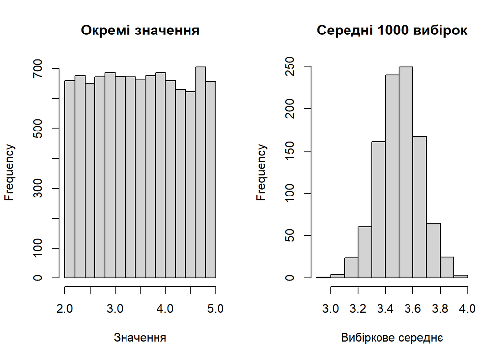

```r
set.seed(2026)
population <- runif(10000, min = 2, max = 5)
n <- 30
means <- replicate(1000,mean(sample(population, size = n)))

par(mfrow = c(1, 2)) # поділ графічного вікна на дві частини (колонки)
hist(population, main = "Окремі значення", xlab = "Значення")
hist(means, main = "Середні 1000 вибірок", xlab = "Вибіркове середнє")
```

1. Який із двох розподілів більше нагадує нормальний?
2. Чи обов'язково сама генеральна сукупність має бути нормально розподілена, щоб розподіл вибіркових середніх наближався до нормального?
3. Повторіть моделювання для n = 5 та n = 100. Як змінюється розкид вибіркових середніх та медіан? Чому? Яка статистика більш ефективна, якщо була зібрана випадкова вибірка і викидів не має

   при n = 5 розкид оцінок стає ширшим при n = 100 розкид оцінок стає ширшим медіана більш ефективна міра центральної тенденції середнє арифметичне більш ефективна міра центральної тенденції

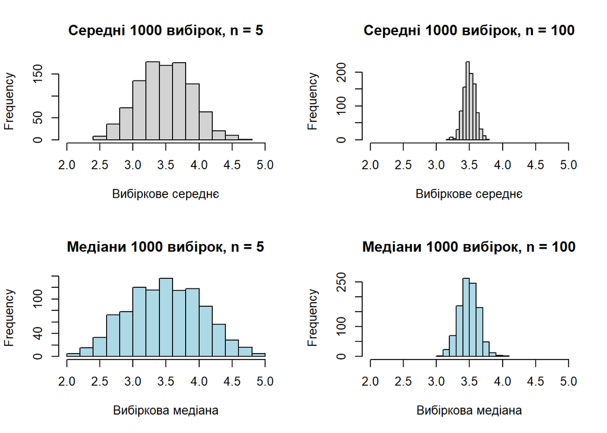

```r
par(mfrow = c(2, 2)) # поділ графічного вікна на чотири частини
hist(replicate(1000,mean(sample(population, size = 5))),
     main = "Середні 1000 вибірок, n = 5", xlab = "Вибіркове середнє",
     xlim = range(population))        # тут задала розкид значень по осі Х
hist(replicate(1000,mean(sample(population, size = 100))),
     main = "Середні 1000 вибірок, n = 100", xlab = "Вибіркове середнє",
     xlim = range(population))
hist(replicate(1000,median(sample(population, size = 5))),
     main = "Медіани 1000 вибірок, n = 5", xlab = "Вибіркова медіана",
     xlim = range(population),
     col="lightblue")                 # тут змінила колір гістограми
hist(replicate(1000,median(sample(population, size = 100))),
     main = "Медіани 1000 вибірок, n = 100", xlab = "Вибіркова медіана",
     xlim = range(population),
     col="lightblue")
```

## 3 Перевірка відповідності розподілу

Змоделюйте два набори даних: один із нормального, а інший — із логнормального розподілу. Зробіть для обох змінних QQ-графік.

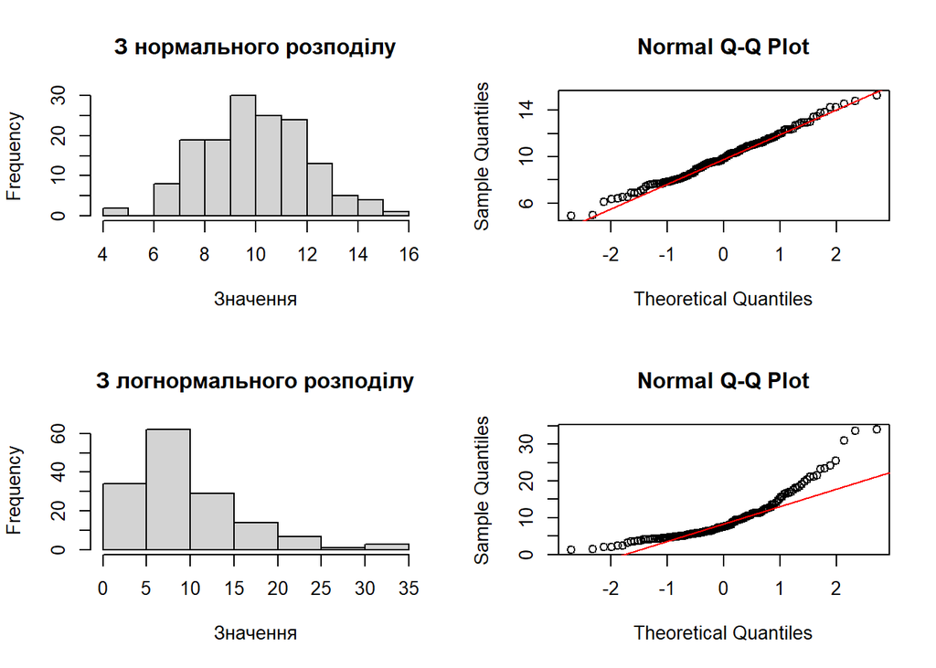

```r
set.seed(2026)
x_normal <- rnorm(150, mean = 10, sd = 2)
x_lognormal <- rlnorm(150, meanlog = 2, sdlog = 0.7)

par(mfrow = c(2, 2)) # Ділить графічне вікно на 2 колонки.
hist(x_normal, main = "З нормального розподілу", xlab = "Значення")
qqnorm(x_normal)
qqline(x_normal, distribution=qnorm,col = "red") # теоретичні квантилі нормального розподілу

hist(x_lognormal, main = "З логнормального розподілу", xlab = "Значення")
qqnorm(x_lognormal)
qqline(x_lognormal, distribution=qnorm,col = "red")
```

1. Зробіть тест Шапіро—Вілка. Чи доводить велике `p-value`, що дані точно нормально розподілені? Яка потужність теста при різних розмірах вибірок.

Переглянути тут, хоча б Рис.1

https://www.researchgate.net/publication/267205556_Power_Comparisons_of_Shapiro-Wilk_Kolmogorov-Smirnov_Lilliefors_and_Anderson-Darling_Tests

```
##
##  Shapiro-Wilk normality test
##
## data:  x_normal
## W = 0.99315, p-value = 0.6967
```

```
##
##  Shapiro-Wilk normality test
##
## data:  x_lognormal
## W = 0.85544, p-value = 7.821e-11
```

2. Перевірте логарифмовані значення `log(x_lognormal)` за допомогою QQ-графіка й `shapiro.test()`. Що змінилося?
3. Який ваш висновок? Щодо ефективності log-трансформації з питання (2). Гіпотеза про нормальність:

   приймається відкидається

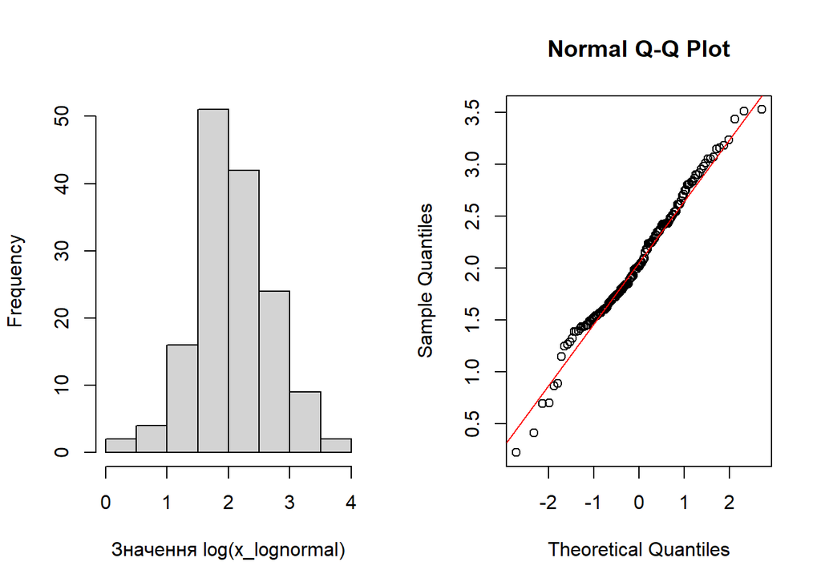

## 4 Багаторазове тестування

Дослідник перевіряє 36 змінних і виконує всі попарні кореляції. Припустімо, що всі нульові гіпотези насправді правильні, а кожен тест має рівень значущості $\alpha$ = 0.05. Виконайте строки коду і знайдіть відповідь.

Зв'язку не має, кореляція = 0

```r
n_variables <- 36
n_tests <- choose(n_variables, 2)
# або дивіться всі можливі комбінації
# з функцією combn(n_variables, 2)

alpha <- 0.05

expected_false_positives <- n_tests * alpha

prob_at_least_one <- 1 - (1 - alpha)^n_tests
```

1. Скільки парних тестів буде виконано?

   36 630 648
2. Яку кількість помилок першого роду ми теоретично можемо допустити (хибнопозитивні тести)?

   майже 2: кількість змінних * альфа майже 32: кількість тестів * альфа не можливо визначити
3. Яка ймовірність отримати рівно один хибнопозитивний результат? При альфа = 0.05, кількості тестів = 10

   майже 32% майже 62% не можливо визначити

Або згадайте формулу біноміального розподілу (https://en.wikipedia.org/wiki/Binomial_distribution),

або порахуйте в R:

```r
dbinom(1, size = 10, prob = 0.05) # ймовірність отримати рівно один хибнопозитивний результат
```

[1] 0.3151247

```r
dbinom(0, size = 10, prob = 0.05) # ймовірність отримати 0 хибнопозитивних результатів (тобто взагалі не помилитись)
```

[1] 0.5987369

```r
1 - dbinom(0, size = 10, prob = 0.05) # ймовірність отримати хибнопозитивних результатів в одному та більше тестах
```

[1] 0.4012631

```r
sum(dbinom(1:10, size = 10, prob = 0.05)) # те саме що і попереднє, але через суму ймовірностей
```

[1] 0.4012631

4. Що таке p-hacking і чому пошук значущих результатів серед багатьох непланованих аналізів збільшує ризик хибних висновків?
5. Дослідник перевіряв відмінності між групами за чотирма змінними і отримав такі `p-values`

```r
p.values <- c(0.021, 0.023, 0.020,0.030)
```

Яке твердження використати досліднику в публікації?

Аналіз результатів продемонстрував наявність статистично значущих відмінностей між досліджуваними групами за всіма чотирма показниками. Первинні значення критерію для кожного з порівнянь виявилися стабільно нижчими за загальноприйнятий поріг значущості (alpha = 0.05). Отримані дані дозволяють відхилити нульову гіпотезу про рівність груп та свідчать про наявність чітко вираженого ефекту З урахуванням множинних порівнянь та застосування корекції Бонферроні, виявлені відмінності між групами втратили статистичну значущість (найменше скориговане значення p = 0.080). Отже, наявні дані не дають підстав відхилити нульову гіпотезу

```r
p.adjust(p.values,method="bonferroni")
```

```
## [1] 0.084 0.092 0.080 0.120
```